# The Office Report

Carlos Omar Pardo, Antonio Lopez Ruiz, Jose Lopez Torres

December 3, 2018

# Introduction

## Instructions: Explain why you chose this topic, and the questions you are interested in studying.

This team (just like over 6 million viewers per episode) has enjoyed watching this show, and decided to use our data visualization techniques to ask some complex questions about the series. We were motivated to have a better understanding over the series in a quantitative manner, by creating a framework with three types of questions. We expect to be able to solve them mostly based on the data we obtained from the scripts and other web sources, rather than from our experience as audience.

Can we get a better understanding on each character’s specific profile, like who says the most jokes, or who holds the most airtime?

Can this dataset help us understand something about the interaction among the characters, like who mentions whom the most times, or how many scenes are shared by groups like Michael and Dwight, or Jim and Pam?

Finally, would the scripts help us understand any impact the show might have had on society? For instance, do males play a bigger role on the show? How did viewership change as time passed and how did it react to changes in the original cast?

Using these questions as a starting point, we dived into our database and expanded it by using information that we deemed appropriate, but wasn’t in it originally.

## Instructions: List team members and a description of how each contributed to the project This goes last within the section.

As a team, each one of us contributed to every general task (cleaning, analysis, documentation, presentation and interactivity) in order to practice the skills we learnt in class. In broader terms, each one contributed more strongly in the area that suit them best: Omar focused in the data cleaning process, creating functions that would ease this process throughout the project as we found obstacles. Antonio worked in planning the interactive component, thinking what visualizations should be included and how to help the audience understand the information we would eventually give them. Jose worked in the general structure of the document, and assigning the analyses to their appropriate sections. We also made an effort to share our knowledge by solving each other’s questions and agreeing on how to advance in the exploration of our dataset, in order to maximize our learning from the assignment.

# Description of Data

## Instructions: Describe how the data was collected, how you accessed it, and any other noteworthy features.

Thanks to the show’s large number of fans there are several websites dedicated to different aspects of the series. We found a repository from a fan’s blog, called Officequotes.net. This repository includes every dialogue from the script, specifying the season, episode and scene in which it was said, as well as its speaker and whether the scene was edited out of the show or not.

The data is stored as a Google Sheet [here](https://docs.google.com/spreadsheets/d/18wS5AAwOh8QO95RwHLS95POmSNKA2jjzdt0phrxeAE0/edit#gid=747974), so we reviewed it to understand the conditions it was in. In general, the dataset was properly structured -which eased the cleaning process. The tasks we followed are described in detail on the next session of the report.

Furthermore, one of the questions required us to retrieve data that wasn’t available on the original dataset. We found ratings at a per-episode level in wikipedia.org (which took this information from nielsen.com) and copied the information on a csv file. Although the ratings correspond to the original airdate’s audience, we assume that this factor is a constant (i.e, it is a fair comparisson to evaluate conclusions about viewership for any episode in the seried based on the rating recieved during its first cast), and used it for our project. We also created a table with the main cast and the gender of each character in order to include this factor in our analysis. The genders were populated manually into the csv file.

An important element in the analysis of the dialogues was the selection of a stopword dictionary, to drop (and analyze) common words in the language, so that we only retained meaningful information in our dataset. We used the (stopwords) default library for this matter.

# Analysis of data quality

## Instructions: Provide a detailed, well-organized description of data quality, including textual description, graphs, and code.

In order to assess the data quality, we set up a few tasks to inspect different questions about the transcripts: Were conversations missing? Was a certain standard on names followed? Could we really find answers to the questions we were hoping for with the information that was gathered?

First, we inspected the general structure of the original dataframe. The scripts included 7 variables as previously discussed, and we understood it was necessary to use the numbers as categorical data rather than integers (since they represent episodes, scenes, seasons, etc.) and the speaker names as factors, rather than character strings. This idea helped us realize that there were some typos in the names of the characters in the dataframe, which we started fixing.

### Help: Also, a lot of different combinations are missing, like micahel for michael

```r
glimpse(theoffice_df)
```

```
## Observations: 59,909
## Variables: 7
## $ id        <int> 1, 2, 3, 4, 5, 6, 7, 8, 9, 10, 11, 12, 13, 14, 15, 1...
## $ season    <int> 1, 1, 1, 1, 1, 1, 1, 1, 1, 1, 1, 1, 1, 1, 1, 1, 1, 1...
## $ episode   <int> 1, 1, 1, 1, 1, 1, 1, 1, 1, 1, 1, 1, 1, 1, 1, 1, 1, 1...
## $ scene     <int> 1, 1, 1, 1, 1, 2, 3, 3, 3, 3, 3, 3, 3, 3, 3, 4, 5, 6...
## $ line_text <chr> "All right Jim. Your quarterlies look very good. How...
## $ speaker   <chr> "Michael", "Jim", "Michael", "Jim", "Michael", "Mich...
## $ deleted   <lgl> FALSE, FALSE, FALSE, FALSE, FALSE, FALSE, FALSE, FAL...
```

Furthermore, a character might have been referenced in different ways throughout the show, like “Todd Packer” for “Todd”, or “Robert California” for “Robert”. Also, standardizing names in lower case would facilitate the process later, so we also included that adjustment.

Having a list of characters, and knowing who belong to the main cast, we created a palette for consistency. We assigned a specific color to each speaker, making sure that it was compliant with the guidelines for color perception deficiencies.

```r
knitr::opts_chunk$set(error = TRUE)
#visna(theoffice_df, sort = "b")
```

This was great progress to start our analysis, as we could now focus on the text of the actual dialogues, the main point of this project. We followed the process by removing the wrylies, which allowed us to focus on dialogues rather than instructions. We also dropped punctuation and removed capitalization from the document. Finally, we tied common expressions throughout the series, joining each word by an underscore, in order to avoid dropping the stopwords on these expressions later in the project.

### Help: Note: Description about ngrams

The file with the whole set up of data clean-up functions and the process rests in ’file=“../Cubicles/Omar/clean_data.R’ for your review.

# Main Analysis

## Instructions: Provide a detailed, well-organized description of your findings, including textual description, graphs, and code. Your focus should be on both the results and the process. Include, as reasonable and relevant, approaches that didn’t work, challenges, the data cleaning process, etc.

Now that the data had been cleaned, we can move on to figuring out what relevant information can be obtained about the characters, their interactions, and get a better understanding of the series. We are following the framework we devised at the beginning of the project.

## What can we learn about individual characters?

Upon organizing the dataset, we realized that one of the most obvious quesitons was if it was possible to determine what characters have the most lines in the show.

```r
dialogues_by_char <- dialogues_df %>%
  group_by(speaker) %>%
  summarise(Freq = n()/1000) %>%
  arrange(Freq) %>%
  top_n(15)
```

```
## Error in eval(lhs, parent, parent): object 'dialogues_df' not found
```

```r
dialogues_by_char$speaker <- as.factor(dialogues_by_char$speaker)
```

```
## Error in is.factor(x): object 'dialogues_by_char' not found
```

```r
plot(ggplot(dialogues_by_char, aes(x = reorder(speaker, -Freq), y = Freq, fill= speaker)) +
  geom_bar(stat = 'identity', colour='black') +
  labs(title = "Michael, Dwight and Jim speak the most lines in the series",
       x = "Character",
       y="Number of lines (in thousands)") +
  scale_colour_manual(values = MyPalette, aesthetics = "fill")) +
  theme(legend.position="none")
```

[output not shown]

```
## Error in ggplot(dialogues_by_char, aes(x = reorder(speaker, -Freq), y = Freq, : object 'dialogues_by_char' not found
```

But does this mean these characters really speak the most? We want to eliminate the possibility that a speaker says several very short lines, which might make them get into the main cast without actually developing a character in the show.

```r
words_by_char <- words_df %>%
  group_by(speaker) %>%
  summarise(Freq = n()/1000) %>%
  arrange(-Freq) %>%
  top_n(15)
```

```
## Error in eval(lhs, parent, parent): object 'words_df' not found
```

```r
words_by_char$speaker <- as.factor(words_by_char$speaker)
```

```
## Error in is.factor(x): object 'words_by_char' not found
```

```r
ggplot(words_by_char, aes(x = reorder(speaker, -Freq), y = Freq, fill= speaker)) +
  geom_col(color = 'black') +
  labs(title = "Michael, Dwight and Jim also speak the most words in the show",
       x = "Character",
       y="Number of words (in thousands)") +
  scale_colour_manual(values = MyPalette, aesthetics = "fill") +
  theme(legend.position="none")
```

[output not shown]

```
## Error in ggplot(words_by_char, aes(x = reorder(speaker, -Freq), y = Freq, : object 'words_by_char' not found
```

The next step to determine if the distribution of screen time is proportional indeed, we would like to find out if there is a relation between the average characters per line of speech for each character, and the maximum length of a line they delivered in the show.

```r
dialogues_df <- wrylies_dialogue_df %>%
  filter(!deleted) %>%
  select(id, season, episode, scene, speaker, dialogue) %>%
  mutate(filt_dialogue = clean_text(dialogue, ct_list), dialogue_length = nchar(filt_dialogue))
```

```
## Error in eval(lhs, parent, parent): object 'wrylies_dialogue_df' not found
```

```r
dialogue_length_df <- dialogues_df %>%
  select (speaker, dialogue_length) %>%
  group_by(speaker) %>%
  summarize (avg_d_length = sum(dialogue_length)/n(), max_dialogue = max(dialogue_length)) %>%
  top_n(15)
```

```
## Error in eval(lhs, parent, parent): object 'dialogues_df' not found
```

```r
filtered_dial <- gather(dialogue_length_df, attribute, value, -speaker)
```

```
## Error in gather(dialogue_length_df, attribute, value, -speaker): object 'dialogue_length_df' not found
```

```r
ggplot(filtered_dial,
       aes(x = value,
           y = fct_reorder2(speaker,
                            attribute == 'max_dialogue',
                            value,
                            .desc = FALSE))) +
  geom_point(aes(color = attribute)) +
  labs(title = "Do more lines also mean important lines?",
       x = "Number of characters",
       y="Character") +
  theme(legend.position="top",
        legend.title=element_blank() ) +
  scale_colour_discrete(labels=c("Average dialogue", "Longest dialogue"))
```

[output not shown]

```
## Error in ggplot(filtered_dial, aes(x = value, y = fct_reorder2(speaker, : object 'filtered_dial' not found
```

Now that we have our hands in this data, we realized that we can go one level deeper, and replicate at a word level what we just did for dialogues. This might shine some light over a character being portrayed as smarter in the show, as the ability to use more complicated words is linked to the perception of intelligence.

```r
words_df <- dialogues_df %>%
  separate_rows(., filt_dialogue, sep = " ", convert = TRUE) %>%
  rename(word = filt_dialogue) %>%
  filter(word != "") %>%
  mutate(word_length = nchar(word))
```

```
## Error in eval(lhs, parent, parent): object 'dialogues_df' not found
```

```r
word_length_df <- words_df %>%
  select (speaker, word_length) %>%
  group_by(speaker) %>%
  summarize (avg_length = sum(word_length)/n(), max_word = max(word_length)) %>%
  top_n(15)
```

```
## Error in eval(lhs, parent, parent): object 'words_df' not found
```

```r
filtered_word <- gather(word_length_df, attribute, value, -speaker)
```

```
## Error in gather(word_length_df, attribute, value, -speaker): object 'word_length_df' not found
```

```r
ggplot(filtered_word,
       aes(x = value,
           y = fct_reorder2(speaker,
                            attribute == 'max_word',
                            value,
                            .desc = FALSE))) +
  geom_point(aes(color = attribute)) +
  labs(title = "How mong are the words characters use?",
       x = "Number of letters",
       y = "Character") +
  theme(legend.position="top", legend.title=element_blank() ) +
  scale_colour_discrete(labels=c("Average word", "Longest word")) +
  geom_vline(xintercept=4.5)
```

[output not shown]

```
## Error in ggplot(filtered_word, aes(x = value, y = fct_reorder2(speaker, : object 'filtered_word' not found
```

## Just realized this might be linked to that_what_she_said (19 characters). must drop underscores and re-do

This took us to a new question: how commonly do characters use crutch words? Rather than defining a dictionary of these support words, we decided to leverage on what was available and use the stopwords list again. After all, we assumed this would mean that characters that used words different from those in the dictionary carried more meaning in their dialogues.

```r
crutches <- words_df
```

```
## Error in eval(expr, envir, enclos): object 'words_df' not found
```

```r
crutches$crutch <- crutches$word %in% stopwords()
```

```
## Error in crutches$word %in% stopwords(): object 'crutches' not found
```

```r
crutches <- crutches %>%
  mutate(crutch = ifelse(crutch == TRUE,1,0))
```

```
## Error in eval(lhs, parent, parent): object 'crutches' not found
```

```r
count_c <- crutches %>%
  select(speaker,crutch) %>%
  group_by(speaker) %>%
  summarize(freq = n())
```

```
## Error in eval(lhs, parent, parent): object 'crutches' not found
```

```r
aux_c <- count_c[order(-count_c$freq),]
```

```
## Error in eval(expr, envir, enclos): object 'count_c' not found
```

```r
top_c <- head(aux_c,15)
```

```
## Error in head(aux_c, 15): object 'aux_c' not found
```

```r
top_c$freq <- top_c$freq/1000
```

```
## Error in eval(expr, envir, enclos): object 'top_c' not found
```

```r
ggplot(data = top_c, aes(x = fct_reorder(speaker,freq,.desc = TRUE), y = freq, fill= speaker)) +
  geom_bar(stat = 'identity',colour='black') +
  scale_colour_manual(values = MyPalette, aesthetics = "fill") +
  labs(title="Most crutch words by character (in thousands)") +
  labs(x="Character", y="Words") +
  ylim(c(0,160)) +
  theme(legend.position="none")
```

[output not shown]

```
## Error in ggplot(data = top_c, aes(x = fct_reorder(speaker, freq, .desc = TRUE), : object 'top_c' not found
```

## Need to rerun after adding stopwords to understand the effect. Right now, it looks the same.

Given that our dataset has a field that identifies whether a scene was deleted or not, we decided to look into what characters were cut out the most.

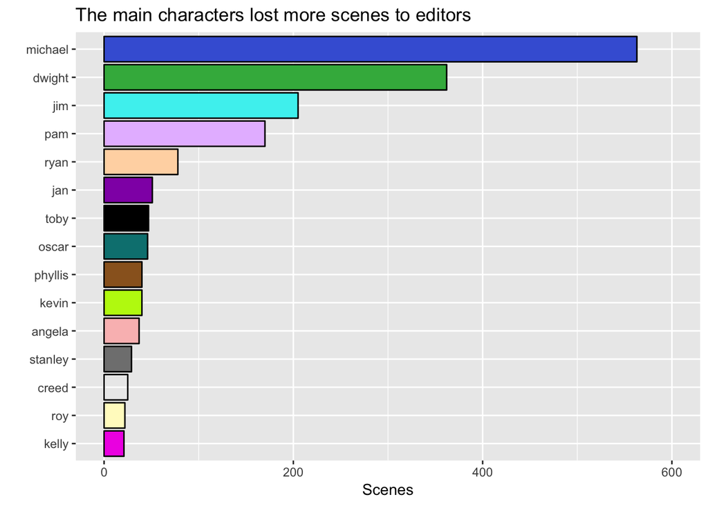

```r
deleted_scenes <- theoffice_df %>%
  filter(deleted == TRUE) %>%
  select(speaker,season) %>%
  group_by(speaker) %>% #,season
  summarize(freq = n())

deleted_scenes$speaker <- tolower(deleted_scenes$speaker)
aux_ds <- deleted_scenes[order(-deleted_scenes$freq),]
top_deleted <- head(aux_ds,15)

#ratings$Season <- as.factor(ratings$Season)
ggplot(data = top_deleted, aes(x = fct_reorder(speaker,freq,.desc = FALSE), y = freq,fill= speaker)) +
  geom_bar(stat = 'identity',colour = 'black') +
  coord_flip() +
  scale_colour_manual(values = MyPalette,aesthetics = "fill") +
  labs(title="The main characters lost more scenes to editors") +
  labs(x="", y="Scenes") +
  ylim(c(0,600)) +
  theme(legend.position="none")
```

Andy wasn’t in this group, however, which caught our attention. We inspected the data and realized that scenes in the script were only labeled as “deleted” for seasons 1 and 2, before he was added to the cast.